# Milestone Report - A language model for predictive text application

Prafful Agrawal

September 15, 2020

### INDEX

**Show/Hide**

- Introduction
- Data Acquisition
- Summary Statistics
- Data Sampling
- Data Preprocessing
- Exploratory Data Analysis
- Discussion
- Appendix
- Session Info

### INTRODUCTION

In the *capstone* project of the **Data Science** specialization offered by **Johns Hopkins University** on *[Coursera](https://www.coursera.org/specializations/jhu-data-science)*, a [language model](https://en.wikipedia.org/wiki/Language_model) is generated which can predict the next word on the basis of previously entered text. The model is then used for developing a *web application* which is deployed on [shinyapps.io.](https://www.shinyapps.io/)

This report covers the following steps of the process:

1. Data acquisition.
2. Generating summary statistics.
3. Sampling data for further analysis.
4. Preprocessing the sample data.
5. Exploratory data analysis.
6. Discussion.

The results from this preliminary analysis were considered during the final development.

*The limited processing power available for this project [32-bit Intel Core 2 CPU with 2 GB of RAM] presented interesting challenges which were tackled by adopting the approach to work under the confines of available resources. This resulted in a valuable learning experience.*

### DATA ACQUISITION

The data for this project is provided by SwiftKey, the corporate-partner for this project. It contains a collection of texts collected through web crawling publicly available sources. The texts were then processed to allow for [fair use.](https://web.archive.org/web/20160930083655/http://www.corpora.heliohost.org/aboutcorpus.html)

The collection is split into four according to 'language' - English, Finnish, German and Russian. It is further divided into three according to 'type' - Blogs, News and Twitter.

The dataset is available at the following link:

- [Coursera-SwiftKey-Dataset](https://d396qusza40orc.cloudfront.net/dsscapstone/dataset/Coursera-SwiftKey.zip).

> Please refer the appendix for the code: Appendix - Acquire data

### SUMMARY STATISTICS

The statistics are computed by importing individual files from the 'English' language dataset and populating the list of statistics followed by the immediate removal of the file from memory. This process was adopted to keep the maximum working memory under check.

> Please refer the appendix for the code: Appendix - Generate summary statistics

Summary Statistics

| File_name | Number_of_documents | Number_of_characters | Size_in_memory |
| --- | --- | --- | --- |
| blogs | 899,288 | 206,824,505 | 238.2 Mb |
| news | 1,010,242 | 203,223,159 | 238.1 Mb |
| twitter | 2,360,148 | 162,096,241 | 274.8 Mb |

It is observed that the number of documents is highest in 'Twitter' followed by 'News' and then 'Blogs'; with 'Blogs' having about 60 % lower documents than 'Twitter'.

Whereas, the number of characters is highest in 'Blogs' followed by 'News' and then 'Twitter'; with 'Twitter' having about 20% lower characters than 'Blogs'.

This may be contributed to the character limit in [Twitter](https://developer.twitter.com/en/docs/counting-characters).

### DATA SAMPLING

As seen above, the files are rather large for memory. Hence, a **5 % random sample** from each of the three files is taken and written to the disk. The analysis is continued on these samples.

> Please refer the appendix for the code: Appendix - Sample data

### DATA PREPROCESSING

During preprocessing, the following steps are carried out:

1. Import sample file (one at a time).
2. Create corpus using the `quanteda` package.
3. Convert corpus to lower case.
4. Implement tokenization.
5. Remove punctuations and separators.
6. Remove numbers and symbols.
7. Remove URLs.
8. Next, remove tokens with only 1 or 2 characters.
9. Remove english stopwords available from the `stopwords` package.
10. Remove profanities available from the `lexicon` package.
11. Generate document feature matrix for each of the first three ngrams (n = 1, 2 and 3).
12. Sort the features according to their frequency in decreasing order.
13. Compile the top 15 features for every ngram.
14. Evaluate number of unique features.
15. Determine total frequency of their occurence.
16. Generate cumulative frequency function for every ngram.
17. Finally, repeat the above process for the remaining sample files.

> Please refer the appendix for the code: Appendix - Preprocess data

### EXPLORATORY DATA ANALYSIS

The *top 15* features are compiled for each and every combination of the files and ngrams. Plots of the resulting features are prepared. Furthermore, among the top 15 features for a given ngram, the number of features common between the three files is evaluated.

> Please refer the appendix for the code: Appendix - Exploratory data analysis 01

The results are given below:

**Show/Hide**

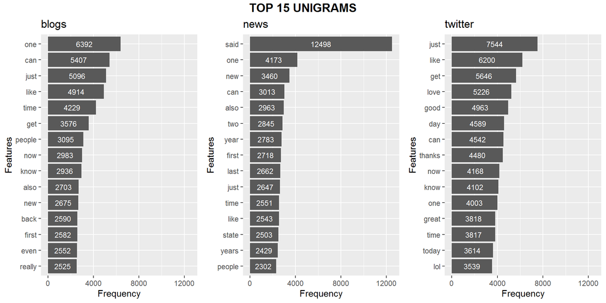

```
Among the top 15 UNIGRAMS, the number of features common between:
 - blogs and news = 9
 - blogs and twitter = 8
 - news and twitter = 5
```

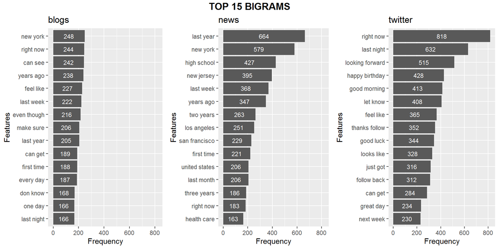

```
Among the top 15 BIGRAMS, the number of features common between:
 - blogs and news = 6
 - blogs and twitter = 4
 - news and twitter = 1
```

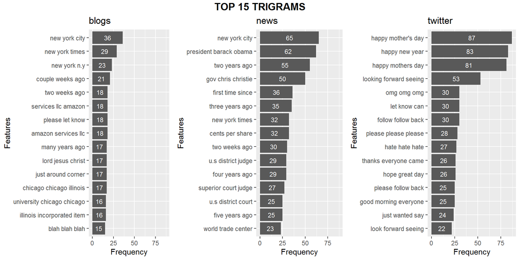

```
Among the top 15 TRIGRAMS, the number of features common between:
 - blogs and news = 3
 - blogs and twitter = 0
 - news and twitter = 0
```

From above, the following observations are made:

- The drop in frequency from a unigram to bigram or from a bigram to trigram is rather steep. For example, in 'Twitter', the frequency for the top unigram is 7544 while for the bigram is 818 and for the trigram is 87, i.e. frequency reduces by a factor of 10 each.
- The number of features common between the three files also decreases moving from unigram to bigram to trigram; reaching *almost zero* for the trigrams.
- The ngram frequencies for 'Blogs' is comparatively lower than that of the ngram frequencies in other files. For example, the frequency for the top bigram in 'Blogs' is about 60 % lower as compared to 'News' and about 70 % lower as compared to 'Twitter'.

**Next,** comparision between the number of *unique* features and their cumulative frequeny of occurence is carried out. Additionally, the number of unique features required to cover 50 % and 90 % of all word occurences is estimated.

> Please refer the appendix for the code: Appendix - Exploratory data analysis 02

The results are given below:

**Show/Hide**

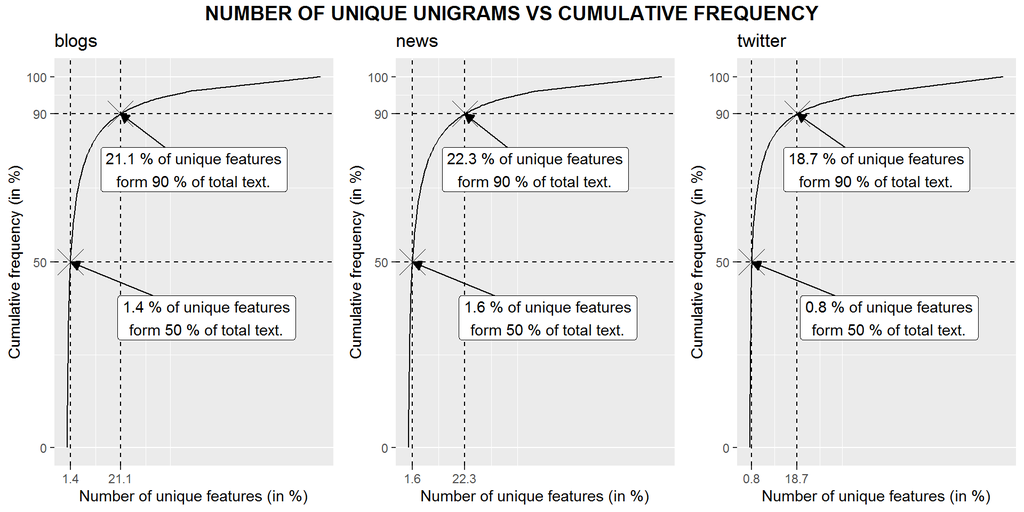

```
FOR UNIGRAMS:
 > In 'blogs'
  - Number of unique features = 69,666
  - Total frequency of occurence = 921,650
 > In 'news'
  - Number of unique features = 74,356
  - Total frequency of occurence = 946,240
 > In 'twitter'
  - Number of unique features = 68,755
  - Total frequency of occurence = 787,605
```

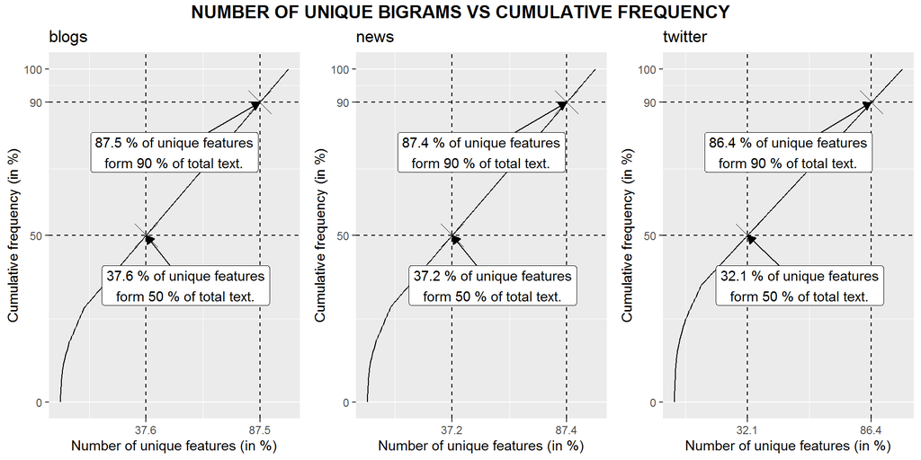

```
FOR BIGRAMS:
 > In 'blogs'
  - Number of unique features = 702,191
  - Total frequency of occurence = 876,901
 > In 'news'
  - Number of unique features = 712,738
  - Total frequency of occurence = 895,807
 > In 'twitter'
  - Number of unique features = 493,266
  - Total frequency of occurence = 670,309
```

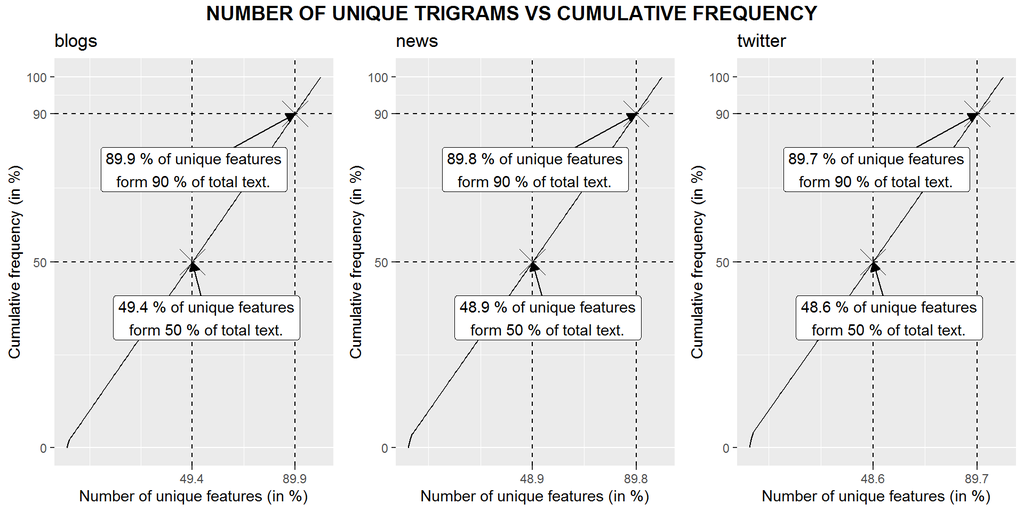

```
FOR TRIGRAMS:
 > In 'blogs'
  - Number of unique features = 824,353
  - Total frequency of occurence = 834,171
 > In 'news'
  - Number of unique features = 828,638
  - Total frequency of occurence = 846,178
 > In 'twitter'
  - Number of unique features = 542,735
  - Total frequency of occurence = 558,072
```

From above, it can be observed that:

- In a frequency sorted list of features, around 1 % of unique unigrams cover 50 % of all word occurences. While, roughly 20 % of unique unigrams are sufficient to cover 90 % of all word occurences. This indicates a small fraction of unigrams constitute majority of text.
- But, for bigrams and trigrams, the cumulative frequency rises almost linearly with the number of unique features, which suggests that almost entire text is formed of unique features.

### DISCUSSION

From this preliminary analysis, we have observed that:

- The files are quite large and hence, sampling is required.
- The stopwords are removed during this analysis. But, in the final model stopwords will be included. This is because they form the bulk of word occurences and their incorporation should increase the model coverage.
- The features vary greatly across the three files with almost zero common features observed in the top 15 trigrams. Hence, it is suggested that a model is trained on one specific file and deployed for the same.
- Alternately, multiple models can be trained on different files and choosen appropriately according to the application.
- Even though a small proportion of unique unigrams form bulk of the text, it is almost entirely made up of unique bigrams and trigrams. Hence, for higher order ngrams, a large memory is required to retain information of the full span of text.

This preliminary analysis was conducted on a *5 % random sample* of the original data. It is recommended to repeat the analysis on another sample of a different proportion.

The development of the final product is greatly benefited from this analysis.

### APPENDIX

#### Acquire data:

**Show/Hide**

```r
# URL of the zip file
url <- paste0("https://d396qusza40orc.cloudfront.net",
              "/dsscapstone/dataset/Coursera-SwiftKey.zip")

# Check and download the zip file
if(!file.exists("Coursera-SwiftKey.zip")) {
  download.file(url, destfile = "Coursera-SwiftKey.zip")
}
```

#### Generate summary statistics:

**Show/Hide**

```r
# Files present in the 'English' language dataset
file_names <- c("blogs", "news", "twitter")

# Paths available in the zip file
all_paths <- unzip("Coursera-SwiftKey.zip", list = TRUE)

# Paths of the files to be extracted
file_paths <-
  grep(pattern = paste0("^.+/en_US\\.", file_names, "\\.txt$",
                        collapse = "|"),
       x = all_paths$Name,
       value = TRUE)

# Reorder paths alphabetically
file_paths <- file_paths[order(file_paths)]

# Initialize variables for summary statistics
n_docs <- vector("numeric", 3)
n_chars <- vector("numeric", 3)
sizes <- vector("numeric", 3)

# Iterate over the files
for(i in 1:length(file_paths)) {
  # Establish the connection
  conn <- unz("Coursera-SwiftKey.zip", file_paths[i])

  # Read the file
  rows <- readLines(conn, encoding = "UTF-8", skipNul = TRUE)

  # Close the connection
  close(conn)

  # Number of documents
  n_docs[i] <- prettyNum(length(rows), big.mark = ",")

  # Number of characters
  n_chars[i] <- prettyNum(sum(nchar(rows)), big.mark = ",")

  # Size of file in memory
  sizes[i] <- format(object.size(rows), units = "Mb")

  # Remove the variables from the memory
  rm(rows)
}

# Summary statistics
summary_statistics <-
  data.frame("File_name" = file_names,
             "Number_of_documents" = n_docs,
             "Number_of_characters" = n_chars,
             "Size_in_memory" = sizes)

# Remove the variables from the memory
rm(all_paths, n_docs, n_chars, sizes)

# Display the summary statistics
knitr::kable(summary_statistics,
             align = "c",
             caption = "Summary Statistics")
```

#### Sample data:

**Show/Hide**

```r
# Create a directory to export the samples
if(!file.exists("./samples")) {dir.create("./samples")}

# Iterate over the files
for(i in 1:length(file_paths)) {
  # Establish the connection
  conn <- unz("Coursera-SwiftKey.zip", file_paths[i])

  # Read the file
  rows <- readLines(conn, encoding = "UTF-8", skipNul = TRUE)

  # Close the connection
  close(conn)

  # Set the seed
  set.seed(1234)

  # Sample a given fraction of rows
  sample_rows <- sample(rows, 0.05 * length(rows))

  # Remove all non-graphical characters
  sample_rows <-
    stringr::str_replace_all(string = sample_rows,
                             pattern = "[^[:graph:]]",
                             replacement = " ")

  # Export the sample to a new file
  write(sample_rows,
        file = paste0("./samples/sample_en_US_",
                      file_names[i], ".txt"))

  # Remove the variables from the memory
  rm(rows, sample_rows)
}
```

#### Preprocess data:

**Show/Hide**

```r
# Import the 'quanteda' package
suppressPackageStartupMessages(library(quanteda))

# Initialize variables for top 15 features
top15_feat <- character()
top15_freq <- numeric()

# Initialize variables for feature frequencies
unq_feat <- numeric()
tot_freq <- numeric()

# Initialize a list for cumulative frequency functions
cum_freq <- vector("list", length(file_names))
names(cum_freq) <- file_names

# Initialize a temporary sub-list
cum_freq_temp <- vector("list", 3)
names(cum_freq_temp) <- c("n1", "n2", "n3")

# Iterate over the files
for(i in 1:length(file_names)) {
  # Establish the connection
  conn <- file(paste0("./samples/sample_en_US_",
                      file_names[i], ".txt"))

  # Read the file
  rows <- readLines(conn, encoding = "UTF-8", skipNul = TRUE)

  # Close the connection
  close(conn)

  # Create a corpus
  db_corpus <- corpus(rows)

  # Convert the corpus to lower case
  db_corpus <- tolower(db_corpus)

  # Tokenize
  db_tokens <- tokens(db_corpus,
                      remove_punct = TRUE,
                      remove_symbols = TRUE,
                      remove_numbers = TRUE,
                      remove_url = TRUE,
                      remove_separators = TRUE)

  # Remove tokens with less than 3 characters
  db_tokens <- tokens_remove(db_tokens, min_nchar = 3)

  # Remove the stopwords
  db_tokens <- tokens_remove(db_tokens,
                             stopwords::stopwords("en"),
                             valuetype = "fixed")

  # Remove the profanities
  db_tokens <- tokens_remove(db_tokens,
                             lexicon::profanity_zac_anger,
                             valuetype = "fixed")

  # Iterate over the ngrams
  for(n in 1:3) {
    # Generate the ngram
    db_ngram <- tokens_ngrams(db_tokens,
                              n = n,
                              concatenator = " ")

    # Document feature matrix
    db_dfm <- dfm(db_ngram, tolower = FALSE)

    # Sort the features in decreasing order
    db_dfm <- dfm_sort(db_dfm)

    # Top 15 features
    top15_feat <- c(top15_feat, featnames(db_dfm)[1:15])
    top15_freq <- c(top15_freq, unname(featfreq(db_dfm)[1:15]))

    # Feature frequencies
    unq_feat <- c(unq_feat, nfeat(db_dfm))
    tot_freq <- c(tot_freq, sum(featfreq(db_dfm)))

    # Cumulative frequency function
    cum_freq_temp[[paste0("n", n)]] <-
      approxfun(x = (0:nfeat(db_dfm))/nfeat(db_dfm) * 100,
                y = c(0, cumsum(featfreq(db_dfm))/
                        sum(featfreq(db_dfm)) * 100))
  }

  # Collate the cumulative frequency functions
  cum_freq[[i]] <- cum_freq_temp

  # Remove the variables from the memory
  rm(rows, db_corpus, db_tokens, db_ngram, db_dfm)
}

# Compile the top 15 features
top15 <-
  data.frame("feature" = top15_feat,
             "frequency" = top15_freq,
             "ngram" = rep(c("n1", "n2", "n3"),
                           each = 15, times = 3),
             "file" = rep(file_names, each = 45),
             stringsAsFactors = FALSE)

# Compile the feature frequencies
feat_freq <-
  data.frame("unique_features" = unq_feat,
             "total_frequency" = tot_freq,
             "ngram" = rep(c("n1", "n2", "n3"),
                           times = 3),
             "file" = rep(file_names, each = 3),
             stringsAsFactors = FALSE)

# Remove the variables from the memory
rm(unq_feat, tot_freq, top15_feat, top15_freq, cum_freq_temp)
```

#### Exploratory data analysis 01:

**Show/Hide**

```r
# Import the packages
suppressPackageStartupMessages(library(ggplot2))

# Initialize titles
ttl <- c("UNIGRAMS", "BIGRAMS", "TRIGRAMS")

# Iterate over the ngrams
for(n in 1:3) {
  # Extract the ngram from each file
  f1 <- top15[top15$ngram == paste0("n", n) &
                top15$file == file_names[1], ]
  f2 <- top15[top15$ngram == paste0("n", n) &
                top15$file == file_names[2], ]
  f3 <- top15[top15$ngram == paste0("n", n) &
                top15$file == file_names[3], ]

  # Find the maximum limit
  mx <- max(f1$frequency, f2$frequency, f3$frequency)

  # Generate the plots
  p <- lapply(list(f1, f2, f3), function(f) {
    # Initialize the plot
    f %>% ggplot(aes(x = frequency,
                     y = reorder(feature, frequency))) +
      geom_col() +

      # Add the text label
      geom_text(aes(label = frequency),
                color = "white",
                size = 3,
                position = position_stack(vjust = 0.5)) +

      # Add the axis limits
      scale_x_continuous(limits = c(0, mx)) +

      # Add the title and axes labels
      labs(title = f$file[1],
           x = "Frequency",
           y = "Features")
  })

  # Initialize top heading
  top <- grid::textGrob(paste("TOP 15", ttl[n]),
                        gp = grid::gpar(fontface = "bold",
                                        fontsize = 14))

  # Arrange and display the plots
  gridExtra::grid.arrange(p[[1]], p[[2]], p[[3]],
                          nrow = 1,
                          top = top)

  # Number of features common between the files
  cat(paste0("Among the top 15 ", ttl[n],
             ", the number of features common between:",
             "\n - ", f1$file[1], " and ", f2$file[1], " = ",
             length(intersect(f1$feature, f2$feature)),
             "\n - ", f1$file[1], " and ", f3$file[1], " = ",
             length(intersect(f1$feature, f3$feature)),
             "\n - ", f2$file[1], " and ", f3$file[1], " = ",
             length(intersect(f2$feature, f3$feature))))

  # Remove the variables from the memory
  rm(f1, f2, f3, mx, p, top)
}
```

#### Exploratory data analysis 02:

**Show/Hide**

```r
# Iterate over the ngrams
for(n in 1:3) {
  # Generate the plots
  p <- lapply(file_names, function(fname) {
    # Extract the cumulative frequency function
    freq_func <- cum_freq[[fname]][[paste0("n", n)]]

    # Initialize the x-coordinates for the plot
    xcoord <- seq(0, 100, 0.5)

    # Generate the y-coordinates for the plot
    ycoord <- freq_func(xcoord)

    # Determine the x-intercepts
    xint50 <- round(approxfun(ycoord, xcoord)(50), 1)
    xint90 <- round(approxfun(ycoord, xcoord)(90), 1)

    # Construct the text labels
    lab50 <- paste0(xint50, " % of unique features",
                    "\nform 50 % of total text.")
    lab90 <- paste0(xint90, " % of unique features",
                    "\nform 90 % of total text.")

    # Initialize the plot
    g <- ggplot(data = NULL) +
      geom_line(aes(x = xcoord, y = ycoord)) +

      # Add the intercepts
      geom_vline(xintercept = c(xint50, xint90),
                 linetype = "dashed") +
      geom_hline(yintercept = c(50, 90),
                 linetype = "dashed") +
      geom_point(aes(x = c(xint50, xint90),
                     y = c(50, 90)),
                 shape = 4,
                 size = 8) +

      # Add the first text label
      geom_segment(aes(x = 55, xend = xint50,
                       y = 35, yend = 50),
                   arrow = arrow(length = unit(0.25, "cm"),
                                 type = "closed")) +
      geom_label(aes(label = lab50), x = 55, y = 35) +

      # Add the second text label
      geom_segment(aes(x = 50, xend = xint90,
                       y = 75, yend = 90),
                   arrow = arrow(length = unit(0.25, "cm"),
                                 type = "closed")) +
      geom_label(aes(label = lab90), x = 50, y = 75) +

      # Add the axes breaks
      scale_x_continuous(breaks = c(xint50, xint90)) +
      scale_y_continuous(breaks = c(0, 50, 90, 100)) +

      # Add the title and axes labels
      labs(title = fname,
           x = "Number of unique features (in %)",
           y = "Cumulative frequency (in %)")
  })

  # Initialize top heading
  top <- grid::textGrob(paste("NUMBER OF UNIQUE", ttl[n],
                              "VS CUMULATIVE FREQUENCY"),
                        gp = grid::gpar(fontface = "bold",
                                        fontsize = 14))

  # Arrange and display the plots
  gridExtra::grid.arrange(p[[1]], p[[2]], p[[3]],
                          nrow = 1,
                          top = top)

  # Feature frequencies for the ngram
  f <- feat_freq[feat_freq$ngram == paste0("n", n), ]
  f$unique_features <- prettyNum(f$unique_features,
                                 big.mark = ",")
  f$total_frequency <- prettyNum(f$total_frequency,
                                 big.mark = ",")

  # Display the feature frequencies
  cat(paste0("FOR ", ttl[n], ":"),
      paste0(" > In \'", f$file, "\'\n  - ",
             "Number of unique features = ",
             f$unique_features, "\n  - ",
             "Total frequency of occurence = ",
             f$total_frequency),
      sep =  "\n")

  # Remove the variables from the memory
  rm(p, top, f)
}
```